# EDA Swire Cola

Brian Burdick

2023-02-17

Business Problem

Business to Business sales of Swire Coca-Cola represent 10% of their total sales. Swire wants to maximize earning potential of contracts with new restaurants while at the same time ensuring that they win the business by creating a greater offering to the restaurant then their competitors. The offering is based on the projected profitability of the new restaurant. When the restaurants thrive, it creates a loyal and valuable customer and when it doesn’t thrive it represents a significant loss to Swire Coca-Cola. Simply put Swire wants to know the longevity and sales of these restaurants so they can quantify the maximum offerings they can give and still make a profit or walk away from the business altogether.

Analytical Objective

The analytical approach that we may use includes creating models with best-in-class techniques such as xgboost, knn, support vector machines, and logistic regression to identify the best performing models on our target variables which includes the total sales and whether a restaurant will go out of business. Our outcome variable is total profit GROSS_PROFIT_DEAD_NET.

Exploration: Questions, Plots, and interpretation

Customer Questions • How many customers does each sales office serve as a % of total? This table shows that Draper Utah office accounts for 0.1124 or 11.24% of all customers in this data set.This also shows the proportion of all other sales offices.

```
##
##          Alamosa, CO      Albuquerque, NM        Arlington, WA
##         0.0051502996         0.0385034418         0.0337988412
##         Bellevue, WA             Bend, OR            Boise, ID
##         0.0502897044         0.0083939979         0.0349873719
##        Bremerton, WA         Cheyenne, WY           Chinle, AZ
##         0.0132966870         0.0060912197         0.0006933096
## Colorado Springs, CO           Denver, CO           Draper, UT
##         0.0223592334         0.0633635418         0.1123656713
##             Elko, NV           Eugene, OR        Flagstaff, AZ
##         0.0030208488         0.0129005101         0.0098549002
##         Glendale, AZ Glenwood Springs, CO   Grand Junction, CO
##         0.0418461843         0.0121081563         0.0138661913
##    Huachuca City, AZ      Idaho Falls, ID        Johnstown, CO
##         0.0066359630         0.0110186698         0.0307037092
##          Kingman, AZ         LaGrande, OR         Lewiston, ID
##         0.0091368296         0.0030951320         0.0098549002
##            Logan, UT            Ogden, UT        Pendleton, OR
##         0.0083444758         0.0260486307         0.0045312732
##        Pocatello, ID         Prescott, AZ            Price, UT
##         0.0096072897         0.0091863517         0.0048779280
##           Pueblo, CO             Reno, NV        Richfield, UT
##         0.0099044223         0.0339474075         0.0060416976
##      Scottsbluff, NE         Show Low, AZ          Spokane, WA
##         0.0056455207         0.0041598574         0.0259000644
##           Tacoma, WA            Tempe, AZ           Tucson, AZ
##         0.0516020403         0.0895854999         0.0305056208
##       Twin Falls, ID      Walla Walla, WA        Wenatchee, WA
##         0.0142623681         0.0036151141         0.0143366513
##      Wilsonville, OR             Yuma, AZ
##         0.0867875006         0.0077749715
```

• How many customers does each delivery plant have? This is the proportion of customers served by each delivery plant. With Draper Utah having 11.24% of all customers i find it interesting that the Draper delivery plant serves roughly the same percentage of customers at 11.24%

```
##
##             Alamosa, CO         Albuquerque, NM           Arlington, WA
##            0.0051502996            0.0385034418            0.0337988412
##            Bellevue, WA                Bend, OR               Boise, ID
##            0.0502897044            0.0083939979            0.0349873719
##           Bremerton, WA            Cheyenne, WY              Chinle, AZ
##            0.0132966870            0.0060912197            0.0006933096
##    Colorado Springs, CO              Denver, CO              Draper, UT
##            0.0223592334            0.0633635418            0.1123656713
##                Elko, NV              Eugene, OR           Flagstaff, AZ
##            0.0030208488            0.0129005101            0.0098549002
##            Glendale, AZ    Glenwood Springs, CO      Grand Junction, CO
##            0.0510325360            0.0121081563            0.0138661913
##       Huachuca City, AZ         Idaho Falls, ID           Johnstown, CO
##            0.0053731491            0.0110186698            0.0307037092
##             Kingman, AZ            LaGrande, OR            Lewiston, ID
##            0.0091368296            0.0030951320            0.0098549002
##               Logan, UT               Ogden, UT           Pendleton, OR
##            0.0083444758            0.0260486307            0.0045312732
##           Pocatello, ID               Price, UT              Pueblo, CO
##            0.0096072897            0.0048779280            0.0099044223
##                Reno, NV           Richfield, UT         Scottsbluff, NE
##            0.0339474075            0.0060416976            0.0056455207
##            Show Low, AZ             Spokane, WA Tacoma Sales Center, WA
##            0.0041598574            0.0259000644            0.0516020403
##               Tempe, AZ              Tucson, AZ          Twin Falls, ID
##            0.0895854999            0.0317684346            0.0142623681
##         Walla Walla, WA           Wenatchee, WA         Wilsonville, OR
##            0.0036151141            0.0143366513            0.0867875006
##                Yuma, AZ
##            0.0077749715
```

• What is the distribution of Activity Cluster 54% of all distribution is from Eating&Drinking, 9.28% is Entertainment and Recreation, 2.46% is grocery stores. I found the educational percentage to be lower then i would have expected at 3.09%. This table shows the proportion of activity cluster.

```
##
##              At-Work    Eating & Drinking          Educational
##           0.06234834           0.53998911           0.03087704
## Entertainment/Recrea     Grocery Shopping Other Shopping & Ser
##           0.09277968           0.02461249           0.14908632
## Third Party (Non-Con Travel/Transportatio
##           0.05823800           0.04206903
```

• What is the distribution of Trade Cluster Full Service and Quick Service Restaurants are 16.51% and 25.48% which represents the majority of the cluster. This percentage makes sense as to why we would want to figure out the sales and longevity of restaurants in particular. Perhaps when we train our model we will focus our efforts on building a model to predict Full Service and Quick Service Restaurants. During the presentation they had mentioned that the soda machines cost about $15,000 a piece and in many cases are lost if the company goes under. Seems to me like a lot of the financial risk in the discounts they offer is whether or not they provided one of these machines?

```
##
##            All Other            Amusement  Automotive Services
##          0.054994305          0.047863121          0.044198485
##  Bar/Tavern/Licensed Business & Professio   College/University
##          0.045486060          0.026395285          0.010993909
##           Drug Store Full Service Restaur General Merchandiser
##          0.002377061          0.165106720          0.079557272
## Government (Non-Mili      Health/Hospital Industrial/Agricultu
##          0.009607290          0.017184173          0.005224583
##              Leisure              Lodging             Military
##          0.007477839          0.038156787          0.003937008
## Other Eating & Drink Primary/Secondary Sc Quick Service Restau
##          0.062472144          0.019883128          0.254791264
##           Recreation Retail Specialty Ser Specialty Food Store
##          0.037438716          0.022953499          0.019214579
##        Street Vendor          Supermarket       Transportation
##          0.012132917          0.005397910          0.003912247
##            Wholesale
##          0.003243698
```

• What is the distribution of sub trade

```
##
##              Airline Amusement/Theme Park B2B CONTRACTUAL DIST
##         1.956123e-03         2.953994e-02         1.569851e-02
## Books/Office/News/To              Bottler  Bottler House Sales
##         2.624672e-03         9.904422e-05         9.904422e-05
##     Cart/Mobile Food         Cinema/Movie Conventional Indepen
##         1.213292e-02         6.982618e-03         2.377061e-03
## ECOMMERCE LARGE STOR EDUCATION - NON REST        FSR-All Other
##         5.397910e-03         1.738226e-02         1.651067e-01
##   FULL LINE OPERATOR      Gaming Facility Hardware/Home-Improv
##         3.446739e-02         6.041698e-03         1.829842e-02
## ISD CONTRACTUAL DIST        Middle School     Military - Other
##         4.828406e-03         4.704601e-04         3.937008e-03
##      Other Amusement Other Automotive Ser Other Bar/Tavern/Lic
##         6.413113e-03         4.419848e-02         4.548606e-02
## Other Business And P Other College/Univer Other Eating & Drink
##         2.639529e-02         1.099391e-02         6.247214e-02
## Other General Mercha Other Government (No Other Health/Hospita
##         5.863418e-02         9.607290e-03         1.718417e-02
## Other Industrial/Agr        Other Lodging     Other Recreation
##         5.224583e-03         3.815679e-02         3.258555e-02
## Other Retail Service Other Specialty Food Other Transportation
##         2.295350e-02         1.921458e-02         1.956123e-03
##       Primary School            QSR-Asian          QSR-Chicken
##         2.476106e-04         2.104690e-02         8.691131e-03
##        QSR-Hamburger          QSR-Mexican  QSR-Other Fast Food
##         4.335661e-02         4.456990e-02         9.060070e-02
##            QSR-Pizza         QSR-Sandwich Religious/Charitable
##         4.194523e-02         4.580795e-03         3.763680e-03
## Residential Complex/ Secondary/High Schoo Social Club/Fraterna
##         1.039964e-03         1.782796e-03         1.436141e-03
##          Sport Venue  Sports/Country Club           Wholesaler
##         4.927450e-03         4.952211e-05         3.045610e-03
```

```
##
##              Airline Amusement/Theme Park B2B CONTRACTUAL DIST
##         1.956123e-03         2.953994e-02         1.569851e-02
## Books/Office/News/To              Bottler  Bottler House Sales
##         2.624672e-03         9.904422e-05         9.904422e-05
##     Cart/Mobile Food         Cinema/Movie Conventional Indepen
##         1.213292e-02         6.982618e-03         2.377061e-03
## ECOMMERCE LARGE STOR EDUCATION - NON REST        FSR-All Other
##         5.397910e-03         1.738226e-02         1.651067e-01
##   FULL LINE OPERATOR      Gaming Facility Hardware/Home-Improv
##         3.446739e-02         6.041698e-03         1.829842e-02
## ISD CONTRACTUAL DIST        Middle School     Military - Other
##         4.828406e-03         4.704601e-04         3.937008e-03
##      Other Amusement Other Automotive Ser Other Bar/Tavern/Lic
##         6.413113e-03         4.419848e-02         4.548606e-02
## Other Business And P Other College/Univer Other Eating & Drink
##         2.639529e-02         1.099391e-02         6.247214e-02
## Other General Mercha Other Government (No Other Health/Hospita
##         5.863418e-02         9.607290e-03         1.718417e-02
## Other Industrial/Agr        Other Lodging     Other Recreation
##         5.224583e-03         3.815679e-02         3.258555e-02
## Other Retail Service Other Specialty Food Other Transportation
##         2.295350e-02         1.921458e-02         1.956123e-03
##       Primary School            QSR-Asian          QSR-Chicken
##         2.476106e-04         2.104690e-02         8.691131e-03
##        QSR-Hamburger          QSR-Mexican  QSR-Other Fast Food
##         4.335661e-02         4.456990e-02         9.060070e-02
##            QSR-Pizza         QSR-Sandwich Religious/Charitable
##         4.194523e-02         4.580795e-03         3.763680e-03
## Residential Complex/ Secondary/High Schoo Social Club/Fraterna
##         1.039964e-03         1.782796e-03         1.436141e-03
##          Sport Venue  Sports/Country Club           Wholesaler
##         4.927450e-03         4.952211e-05         3.045610e-03
```

Customer Data Questions

• What is the average physical volume purchased? The average physical volume is 36.22 but the minimum is -65832. Are customers able to return purchased items?

```
##      Min.   1st Qu.    Median      Mean   3rd Qu.      Max.
## -65832.00      1.00      5.00     36.22     17.00 136349.00
```

```
##      Min.   1st Qu.    Median      Mean   3rd Qu.      Max.
##  -13902.0      17.6      90.0    1003.8     413.4 2847661.8
```

• What is the profit to COGS per order as a scatter plot? To see a better representation of this data i dropped COGS exceeding 15000 and profit of 10000 to see the plot better. Their does to appear to be a linear relationship between the profit and cost of goods sold. This graph suggests that the more that is sold the more linear the relationship is between profit and cogs. As COGS increase profit also appears to be linear between 0 and 2500

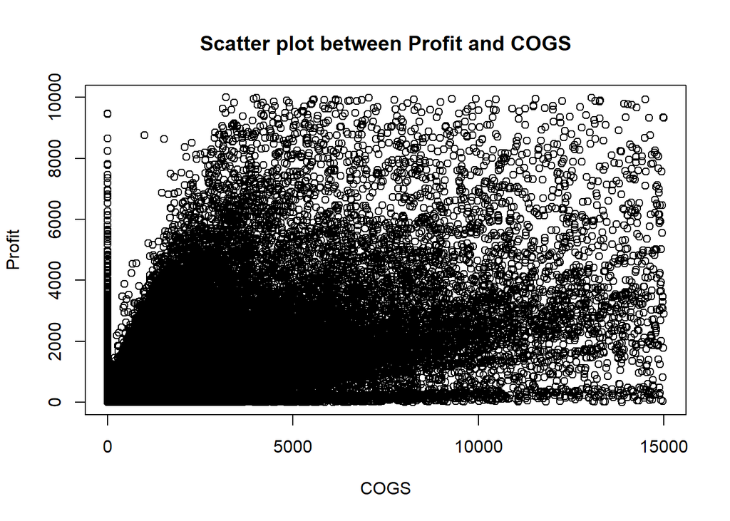

• What does a scatter plot look like between discount and gross profit? Upon doing the scatter plot on the original data set their were outliers that were obscuring the pattern between the x and y variables. I performed a subset of the data on discount at 30,000 and profit at 10,000. This generally shows that the larger the discount the higher the profit.

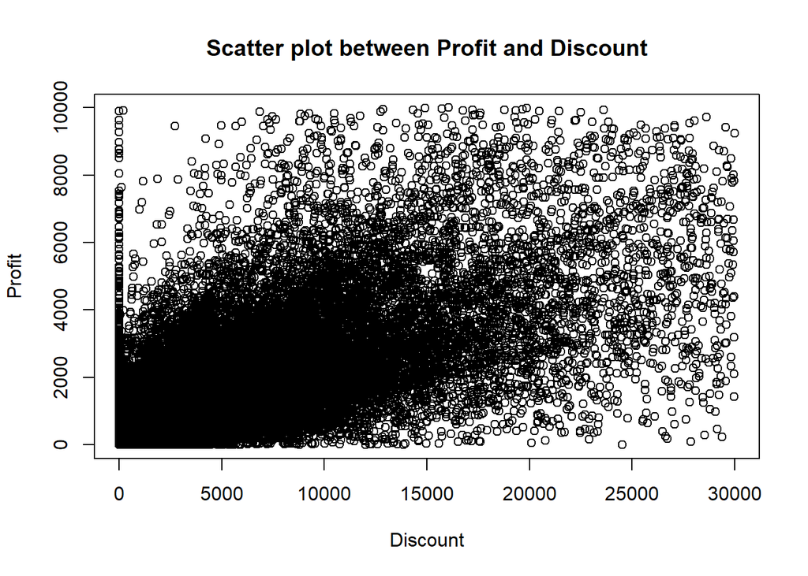

• What does a scatter plot look like between volume and discount? This shows a linear relationship between units purchased and the discount offered where the larger the volume the more of a discount is received. However their is an interesting pattern where a group of orders are showing deeper discounts given their volume purchased of individual products.

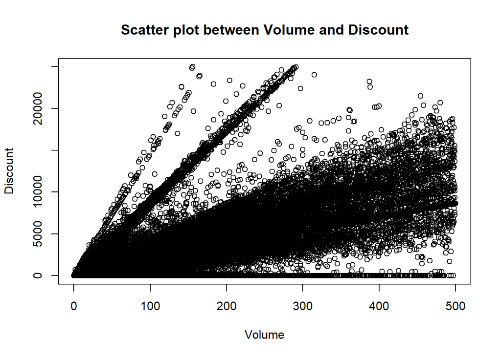

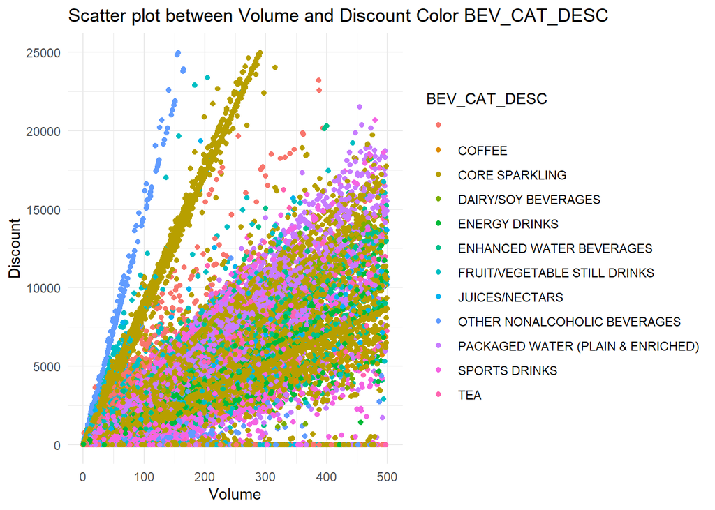

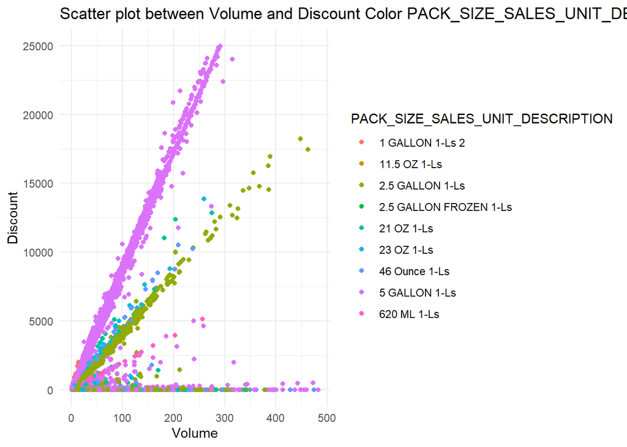

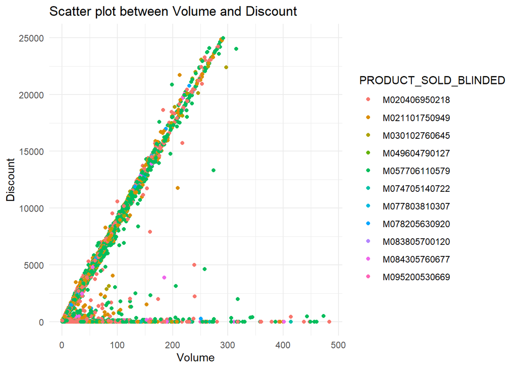

• What is number of transactions vs discount. I would have expected to see a linear relationship between these two variables but am not seeing the pattern.

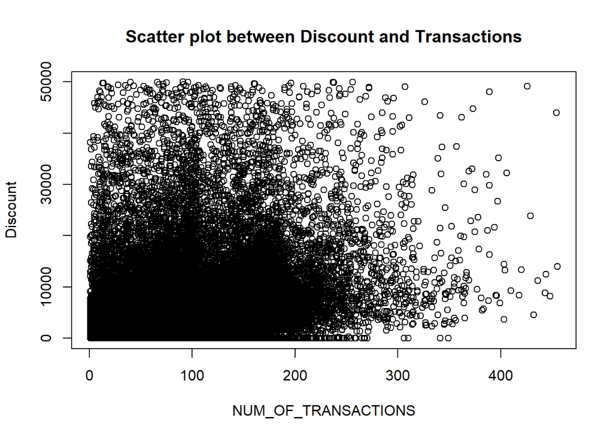

• What is the profit/cogs by discount as a scatter plot? I took the profit and divided it by cogs to get a ratio that i then created a scatter plot on volume to see what the relationship would look like between these. As volume decreases the ratio of profit to COGS increases. This suggests that the more volume that is purchased the better of a discount they get.

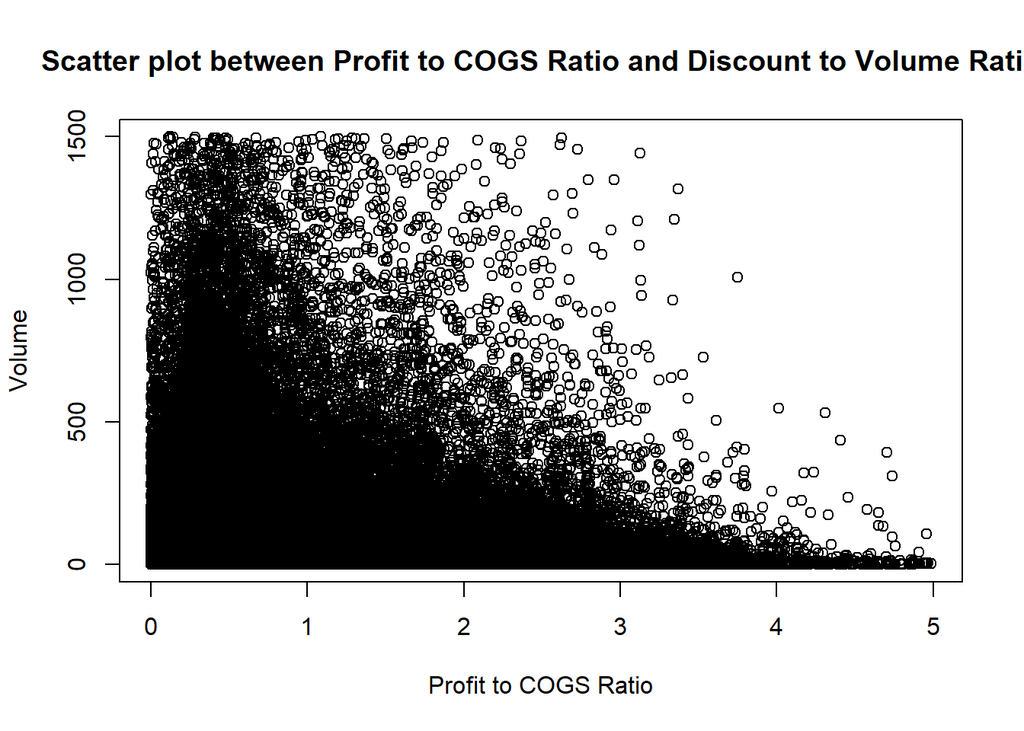

• What does a scatter plot look like between number of transactions and discount? Their does not appear to be a linear relationship between number of transactions and discount.

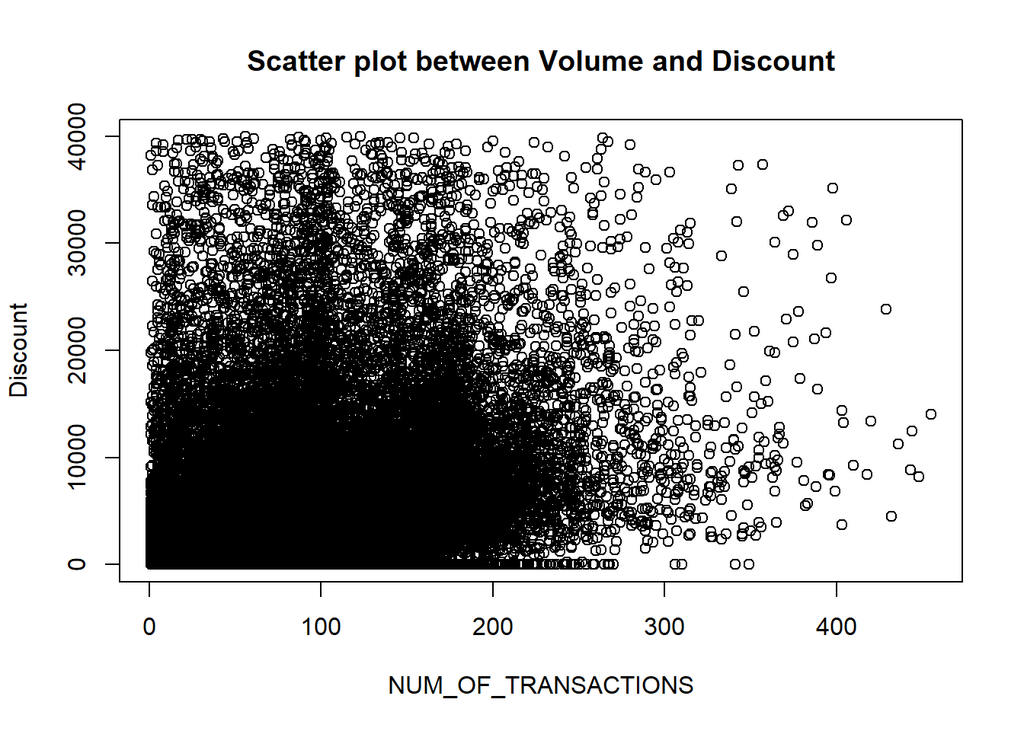

• What is the top 10 best selling products in terms of profit? Best selling of the 10 is M014407280247 with total profit of $17,471,066

```
##    PRODUCT_SOLD_BLINDED GROSS_PROFIT_DEAD_NET
## 1         M014407280247              17471066
## 2         M020406950218               4679629
## 3         M021101750949               4988821
## 4         M034101370588               5095812
## 5         M056203880974              14552971
## 6         M057706110579               8843154
## 7         M065806420519               8371087
## 8         M094400040194               5263259
## 9         M095209660771               4534667
## 10        M098705350190               7742080
```

• Who is the top 10 customers in terms of profit? Our best customer is C0036030908720224 and has made us $2,528,505.70

```
##    CUSTOMER_NUMBER_BLINDED GROSS_PROFIT_DEAD_NET
## 1        C0035002506610939              961642.7
## 2        C0036030908720224             2528505.7
## 3        C0194012007240884             1202710.9
## 4        C0244094103290990             1642260.9
## 5        C0312063707610975             1072519.3
## 6        C0351073308750322             1389203.7
## 7        C0388096700320789              877275.4
## 8        C0525017509730727              946843.1
## 9        C0584085700580916              909308.4
## 10       C0649013904220922              934582.1
```

Results Section

Ethical Considerations If I were Swire I would have had the students sign an NDA or Non Compete agreement. With having the lat and long, discount amount, units, and date of order one could come up with a pretty good idea as to the business name, business model, and where to open up a competing shop.

#Model Building

#Introduction: Business and Analytics Problem

• Swire Coca-Cola wants to maximize their earnings by ensuring that when deep discounts are given they make financial sense for the bottom line. They would like models that can accurately predict longevity of the customer and total sales over a three year period both of which could be predicted by many types of models including linear models, xgboost, NN, and support vector machines.

#Appropriate Models

• These are the models I thought about implementing 1) Linear Model because both of our output variables are numeric. 2) GLM Model: from my experience these seem to perform a little better than regular linear models. 3) Neural Net: these perform really well regardless of whether the predictor variables are linearly related to the outcome variables. 4) Lasso because it penalizes coefficients down to 0 so the model is more generalizable when predicting. I decided to perform the linear and glm models due to being able to train them in a timely manner. I did attempt to do Lasso but after 45 minutes+ of the model training I dropped it and chose not to do the Neural Net for the same reason. I am going to use a linear model and GLM to predict the longevity and 3-year sales.

```r
md <- read.csv(file.choose(), stringsAsFactors = FALSE) #Read in the data to analyze


library(glmnet)
library(caret)
library(tidyr)
```

#Data Preparation and Feature Engineering

• I performed these steps in Excel (had this been a database I would have done this transformation in SQL). The assignment is to calculate the longevity of the business i.e., 1,2,3 years and three years of sales. Since we were only given two years’ worth of historic sales, I multiplied the two years by 1.5 to arrive at estimated three years’ worth of sales. I took the onboard date and max date to arrive on the longevity of the business. I also took any customers with a negative profit and set it to zero so my models wouldn’t be thrown off by negative values.

• On the customer table I performed the following steps to the data 1) Added Field if sales office city was equal to address city, 2) Added Field if sales office was the same city as delivery plant, 3) Standardized zip code to 5 digit, 4) Dropped latitude and longitude, 5) Standardized on boarding date. Upon the completion of that I combined both tables together.

• I added additional columns to the data 1) median income for 2019, 2020, 2021 based on county, 2)median income in county as a percentage of national median, 3) county population and 4) county class.

• The predictor variables I used were Sales = Delivery, sales_office = address_city, CUSTOMER_ACTIVITY_CLUSTER_DESCRIPTION, CUSTOMER_TRADE_CHANNEL_DESCRIPTION, CUSTOMER_SUB_TRADE_CHANNEL_DESCRIPTION, BUSINESS_TYPE_EXTENSION_DESCRIPTION, CUSTOMER_TRADE_CHANNEL_DESCRIPTION2, MARKET_DESCRIPTION, COLD_DRINK_CHANNEL_DESCRIPTION, Population Code Category, year 2019, year 2020, year 2021, % of US Median 2019, % of US 2020, % of US Median 2021, and County Population as predictors. My two outcome variables are longevity and 3 year sales.

#Data Preparation: Variable transformation

• When Swire Coca-Cola go to sell products to new restaurants/customers they will not have information regarding Package size, package, profit, physical volume, invoice price, discount, cogs, or gross profit. I decided to get rid of any information that they would not have going into a sales meeting with a restaurant that hasn’t opened yet. I wanted to see if a meaningful model could be built based on the data they would have going into the sales meeting. I will perform analysis on both of these output variables independent of one another. I split the data into 80% train and 20% test so that I could train the model on 80% and test it on the remaining 20%. I converted categorical variables represented by columns 1 through 10 to factor variables. I dropped sales from the longevity table and longevity from the sales tables because I didn’t want them to be used as predictors for each other so created two data sets to be used in my modeling.

```r
#Converted categorical variables into factor variables.
md[c(1,2,3,4,5,6,7,8,9,10)]<-data.frame(lapply(md[c(1,2,3,4,5,6,7,8,9,10)],factor))

#Changed data type from character to numeric
md$year.2019 <- as.numeric(md$year.2019)
md$year.2020 <- as.numeric(md$year.2020)
md$year.2021 <- as.numeric(md$year.2021)
md$X..of.US.Median.2019 <- as.numeric(md$X..of.US.Median.2019)
md$X..of.US.2020 <- as.numeric(md$X..of.US.2020)
md$X..of.US.Median.2021 <- as.numeric(md$X..of.US.Median.2021)
md$County.Population <- as.numeric(md$County.Population)

#this is longevity data frame that drops the 3 year sales and others as noted above.
mdL <- md[,-18]

#this is sales that drops longevity and others as noted above.
mds <- md[,-19]

#Longevity train and test set
set.seed(1234)
nRows <- nrow(mdL) # gives you the number of rows
train.size.L <- floor(nRows*0.8)
train.index.L <- sample(1:nRows, train.size.L, replace=F)
train.L <- mdL[train.index.L,]
test.L <- mdL[-train.index.L,]

#Sales train and test set
set.seed(123)
nRows <- nrow(mds) # gives you the number of rows
train.size.s <- floor(nRows*0.8)
train.index.s <- sample(1:nRows, train.size.s, replace=F)
train.s <- mds[train.index.s,]
test.s <- mds[-train.index.s,]
```

```r
start <- Sys.time() # Start tracking time
modellml<- lm(Customer.Longevity~.,train.L) #Train model
end <- Sys.time() # End tracking time
predictL <- predict(modellml, data = test.L) #Test model
RMSE(predictL, test.L$Customer.Longevity, na.rm = FALSE) #Model Metric
```

```
## [1] 8.71462
```

```r
print(end-start) # Print run time
```

```
## Time difference of 0.796231 secs
```

```r
start.ls <- Sys.time() # Start tracking time
modellms<- lm(X3.Year.Period.Profit~.,train.s)  #Train model
end.ls <- Sys.time() # End tracking time
predicts <- predict(modellms, data = test.s) #Test model
RMSE(predicts, test.s$X3.Year.Period.Profit, na.rm = FALSE) #Model Metric
```

```
## [1] 49858.8
```

```r
print(end.ls-start.ls) # Print run time
```

```
## Time difference of 0.8810999 secs
```

##GLM Model

```r
start.lg <- Sys.time() # Start tracking time
model.L <- glm(Customer.Longevity ~., data = train.L, family = gaussian) #Train model
end.lg <- Sys.time() # End tracking time
model.Lt <- predict(model.L, data = test.L) #Test model
RMSE(model.Lt, test.L$Customer.Longevity, na.rm = FALSE) #Model Metric
```

```
## [1] 8.720898
```

```r
print(end.lg-start.lg) # Print run time
```

```
## Time difference of 2.681202 secs
```

```r
start.sg <- Sys.time() # Start tracking time
model.s <- glm(X3.Year.Period.Profit~., data = train.s, family = gaussian) #Train model
end.sg <- Sys.time() # End tracking time
model.st <- predict(model.s, data = test.L) #Test model
RMSE(model.st, test.s$X3.Year.Period.Profit, na.rm = FALSE) #Model Metric
```

```
## [1] 49869.27
```

```r
print(end.sg-start.sg) # Print run time
```

```
## Time difference of 1.937769 secs
```

#Evaluation: Strengths and weaknesses of each model and what metric I used to select the best performing model based on the model characterisitics

• Generally speaking, the strengths and weaknesses of these models are as follows. Linear models are popular because they are 1) Easy to implement and interpret by viewing impacts of the coefficient on the dependent variable, 2) can handle large data sets pretty efficiently, 3) ability to use p values to see if the impact of the variable is having a statistically significant impact on the outcome variable. Some of the weaknesses of using a linear model include 1) assumes it is a linear relationship between predictor and outcome variables, 2) can require additional transformations at times, 3) assumes dependent variables have a constant variance across the levels of the independent variables which may or may not be true. A general linearized model has several strengths and weaknesses. Strengths 1) can model a range of different data types, 2) easy to interpret coefficients on the output variable, 3) AIC can be used to compare against other models. Weaknesses include 1) can become complex when multiple predictors are included, 2) data is assumed to follow a specific distribution, 3) can become overfit if there are to many predictors in the model.

#Model Interpretation

#Results and Business Validation